[Back to Main Page](https://skraaij.github.io/)

# MSc Metropolitan Analysis Design Engineering

# Metropolitan Data 1

### Stef Kraaij, Eirini Terezaki, Marco Russo

#### *Assignment 3*

**1. What Amsterdam will receive from tourist tax if the event lasts a week and you will have 30.000 visitors?**

According to [**Hoeben (2023)**](https://esb.nu/grootste-steden-heffen-hoogste-toeristenbelasting/#:~:text=Gemiddeld%20betaal%20je%20als%20toerist,aantal%20gemeenten%20kent%20geen%20toeristenbelasting), the average tourist tax is 3,27 euros per night. The event lasts 7 nights, moreover we know that the total number of visitors is 30,000. €3,27 * 7 nights * 30,000 visitors = €686,700.00

Here a little code to calculate this:

```python
Total_nights = 7
Tourist_tax = 3.27
Total_visitors = 30000
Tax_received = Tourist_tax * Total_nights * Total_visitors

print(Tax_received)
```

```
686700.0
```

So the total amount of tourist tax Amsterdam will receive is €686,700.00.

**2. Plot the amount of AirBnB locations per neighbourhood.**

This is the Python code that calculates how many Airbnb locations are present in each of the 22 neighbourhoods listed in the given CSV file and plots it. Moreover, some lines don’t respect the number of columns assigned. We fixed this by checking that each line of the CSV file has 18 values, the number of columns. We are then excluding some addresses because of some mistakes in the data frame.

```python
import pandas as pd
import matplotlib.pyplot as plt

file_path = 'Assignment_3/listings.csv'

# Read the columns from the first line of the file
with open(file_path, 'r') as file_handle:
    columns = file_handle.readline().strip().split(',')

# Count the number of rows in the file
with open(file_path, 'r') as file_handle:
    n_rows = sum(1 for line in file_handle) - 1  # Subtract 1 for the header

# Create a list of row indices
rows = list(range(1, n_rows + 1))

# Create an empty DataFrame with the specified columns and row indices
grid_Airbnb = pd.DataFrame(columns=columns, index=rows)

# Read and fill the DataFrame with data from the file
with open(file_path, 'r') as file_handle:
    # Skip the first line (header)
    next(file_handle)

    for k, line in enumerate(file_handle, start=1):
        data = line.strip().split(',')
        # Ensure data has the correct number of columns (18)
        if len(data) == 18:
            grid_Airbnb.iloc[k - 1] = data
        else:
            # Handle lines with incorrect number of columns (e.g., by skipping or logging them)
            print(f"Skipping line {k} due to incorrect number of columns: {line}")

neighborhood_counts = grid_Airbnb['neighbourhood'].value_counts()
print(neighborhood_counts)

plt.figure(figsize=(10, 6))  # Adjust the figure size as needed
neighborhood_counts.plot(kind='bar')
plt.title('Neighborhood Counts')
plt.xlabel('Neighborhood')
plt.ylabel('Count')
plt.xticks(rotation=90)  # Rotate x-axis labels for better readability
plt.tight_layout()

# Display the plot
plt.show()
```

After doing this code the program will exclude six rows of data. This is because these rows have an incorrect number of columns. Here the first part of the output:

Skipping line 746 due to incorrect number of columns: 4761760,Rental unit in Amsterdam · ★4.92 · 3 bedrooms · 4 beds · 1 bath,24569854,"Maarten, Linde, Melle En Ilja",,Oostelijk Havengebied - Indische Buurt,52.37065,4.94039,Entire home/apt,270,2,13,2023-08-18,0.15,1,0,2,03639B5990B34125DDE0

Skipping line 810 due to incorrect number of columns: 5432591,Rental unit in Amsterdam · ★4.76 · 1 bedroom · 1 bed · 1 private bath,12607303,"Monique, Fela, Flint",,Oostelijk Havengebied - Indische Buurt,52.37889,4.93095,Private room,120,2,297,2023-08-19,2.89,1,271,60,0363 1BC3 0C25 C2C4 8157

Skipping line 1467 due to incorrect number of columns: 12725921,Home in Amsterdam · ★4.42 · 3 bedrooms · 2 beds · 1.5 baths,4920510,"Niels, Imke, Ravi & Manu",,Oud-Noord,52.39205,4.94383,Entire home/apt,270,2,20,2023-08-07,0.22,1,22,3,0363 6937 1D57 A77E 4246

Skipping line 1756 due to incorrect number of columns: 15256155,Rental unit in Amsterdam · ★5.0 · 2 bedrooms · 2 beds · 1.5 baths,533509,"Harry, Ivana",,Oud-Oost,52.35687,4.91875,Entire home/apt,110,20,12,2019-07-31,0.14,1,0,0,0363 B7B4 3274 CC38 45B7

Skipping line 1939 due to incorrect number of columns: 17050106,Rental unit in Amsterdam · ★4.94 · 1 bedroom · 1 bed · 1 private bath,114456380,"Joost, Cristina And Lima",,De Baarsjes - Oud-West,52.3681,4.86398,Private room,110,4,117,2019-06-03,1.46,1,0,0,0363 7F18 BEC8 AF81 EEFB

Skipping line 2378 due to incorrect number of columns: 21073542,Home in Amsterdam · 4 bedrooms · 4 beds · 1 bath,10926645,"Femke, Jaap Jan",,Oud-Noord,52.3934,4.90731,Entire home/apt,199,3,2,2018-03-11,0.03,1,0,0,0363 5B25 8620 D289 395E

The amount of AirBnB locations per neighbourhood in Amsterdam can be found in second part of the output we got:

[figure not shown]

This is the plot:

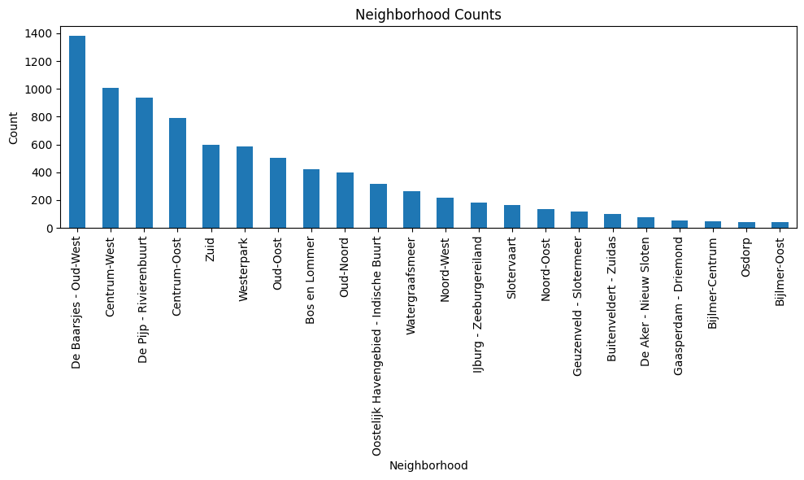

**3 Which street in Amsterdam has the most AirBnB apartments?**

```python
from geopy.geocoders import Nominatim
geolocator = Nominatim(user_agent="AMS")

#Create an empty 'streetname' column in the DataFrame
grid_Airbnb['streetname'] = ""

#Create a dictionary to store the counts of each streetname
streetname_counts = {}

#Iterate through the first 10 rows of your DataFrame
for index, row in grid_Airbnb.iloc[:100].iterrows():
    latitude = row['latitude']
    longitude = row['longitude']

    #Use latitude and longitude to get location information
    coordinates = f"{latitude}, {longitude}"
    location = geolocator.reverse(coordinates, zoom=17)

    #Extract the street name from the location information
    streetname = location.raw.get('address', {}).get('road', 'Unknown')
    grid_Airbnb.at[index, 'streetname'] = streetname

    #Count the occurrence of each street name
    streetname_counts[streetname] = streetname_counts.get(streetname, 0) + 1
#Find the most common street name
most_common_streetname = max(streetname_counts.get(streetname, key=streetname_counts.get))

print(f"The most common street name is: {most_common_streetname}")
```

[output not shown]

**4. Try to cross reference the data from the AirBnB dataset with the BBGA. Can you figure out if all apartments of AirBnB are designated as housing? Which number of apartments are not rented out all the time but are also used as normal housing?**

The Dataset: Basisbestand Gebieden Amsterdam ([**BBGA**](https://api.data.amsterdam.nl/dcatd/datasets/rl6-35tFAw2Ljw/purls/1)) has information about the total number of Airbnb listings (houses or rooms) that were at least once offered on the airbnb platform once a year. That total is 28528 listings. But according to AirBnB the total listings is 8386. So that makes around 20.000 listings that are also used as normal housing.

```python
Airbnb_listings = 8386
BBGA_listings = 28528
Not_airbnb_listed = BBGA_listings - Airbnb_listings

print(Not_airbnb_listed)
```

```
20142
```

We assume that if apartments are available for renting on airbnb for more than half a year (183 days) then they are not designated as housing.

```python
import pandas as pd
import matplotlib.pyplot as plt

file_path = 'Assignment_3/listings.csv'

# Read the columns from the first line of the file
with open(file_path, 'r') as file_handle:
    columns = file_handle.readline().strip().split(',')

# Count the number of rows in the file
with open(file_path, 'r') as file_handle:
    n_rows = sum(1 for line in file_handle) - 1  # Subtract 1 for the header

# Create a list of row indices
rows = list(range(1, n_rows + 1))

# Create an empty DataFrame with the specified columns and row indices
grid_Airbnb = pd.DataFrame(columns=columns, index=rows)

# Read and fill the DataFrame with data from the file
with open(file_path, 'r') as file_handle:
    # Skip the first line (header)
    next(file_handle)

    for k, line in enumerate(file_handle, start=1):
        data = line.strip().split(',')
        # Ensure data has the correct number of columns (18)
        if len(data) == 18:
            grid_Airbnb.iloc[k - 1] = data
        else:
            # Handle lines with incorrect number of columns (e.g., by skipping or logging them)
            print(f"Skipping line {k} due to incorrect number of columns: {line}")

availability_365 = grid_Airbnb['availability_365'].value_counts()
print(availability_365)

grid_Airbnb['availability_365'] = pd.to_numeric(grid_Airbnb['availability_365'], errors='coerce')

# Filter listings with availability more than 183 days
listings_more_than_183 = grid_Airbnb[grid_Airbnb['availability_365'] > 183]

# Count the number of listings that meet the condition
count_more_than_183 = len(listings_more_than_183)

print(f"Number of listings available for more than 183 days: {count_more_than_183}")
```

Number of listings available for more than 183 days: 1733

That makes 1733 of the 8386 not designated as housing according to our definition.

**5. How many hotel rooms should be built if Amsterdam wants to accommodate the same number of tourists?**

```python
Total_visitors = 800000
Weeks_in_year = 52
Average_guests = 2
Needed_hotelrooms = Total_visitors / Weeks_in_year / Average_guests

print(Needed_hotelrooms)
```

```
7692.307692307692
```

We need 7693 hotel rooms.

**6. How many different licences are issued?**

We used a code to find the total unique licenses in the dataset.

```python
unique_license_count = grid_Airbnb['license'].nunique()
print(f'The number of unique licenses is: {unique_license_count}')
```

The number of unique licenses is: 7283

**References**

Dataset: Basisbestand Gebieden Amsterdam (BBGA) | Website onderzoek en statistiek. (z.d.). https://onderzoek.amsterdam.nl/dataset/basisbestand-gebieden-amsterdam-bbga

Hoeben, C. (2023). Grootste steden heffen hoogste toeristenbelasting. ESB. https://esb.nu/grootste-steden-heffen-hoogste-toeristenbelasting/#:~:text=Gemiddeld%20betaal%20je%20als%20toerist,aantal%20gemeenten%20kent%20geen%20toeristenbelasting

Statista. (2023, 2 januari). Number of guests at accommodations in Amsterdam (Netherlands) 2017, by type. https://www.statista.com/statistics/960690/number-of-guests-at-accommodations-in-amsterdam-by-accommodation-type/#:~:text=Premium%20statistics-,Number%20of%20guests%20at%20accommodations,(Netherlands)%202017%2C%20by%20type&text=This%20statistic%20illustrates%20the%20number,guests%20stayed%20in%20an%20